**City College of San Francisco**

MATH 108 - Foundations of Data Science

# Lecture 29: Correlation

Associated Textbook Sections: [15.0, 15.1](https://inferentialthinking.com/chapters/15/1/Correlation.html)

## Set Up the Notebook

```python
from datascience import *
import numpy as np
%matplotlib inline
import matplotlib.pyplot as plots
plots.style.use('fivethirtyeight')

def r_scatter(r):
    plots.figure(figsize=(5,5))
    "Generate a scatter plot with a correlation approximately r"
    x = np.random.normal(0, 1, 1000)
    z = np.random.normal(0, 1, 1000)
    y = r*x + (np.sqrt(1-r**2))*z
    plots.scatter(x, y, color='darkblue', s=20)
    plots.xlim(-4, 4)
    plots.ylim(-4, 4)
```

### Regression Roadmap

- Association and correlation
- Prediction, scatterplots and lines
- Least squares: finding the "best" line for a dataset
- Residuals: analyzing mistakes and errors
- Regression inference: understanding uncertainty

## Prediction

### Guessing the Future

- Based on incomplete information
- One way of making predictions:
  - To predict an outcome for an individual,
  - find others who are like that individual
  - and whose outcomes you know.
  - Use those outcomes as the basis of your prediction.

### Demo: Prediction

Load the `galton.csv` data, and visualization the `MidParent` and `Child` height relationship.

```python
galton = Table.read_table('data/galton.csv')
```

```python
heights = Table().with_columns(
    'MidParent', galton.column('midparentHeight'),
    'Child', galton.column('childHeight')
    )
```

```python
heights
```

| MidParent | Child |
| --- | --- |
| 75.43 | 73.2 |
| 75.43 | 69.2 |
| 75.43 | 69 |
| 75.43 | 69 |
| 73.66 | 73.5 |
| 73.66 | 72.5 |
| 73.66 | 65.5 |
| 73.66 | 65.5 |
| 72.06 | 71 |
| 72.06 | 68 |

... (924 rows omitted)

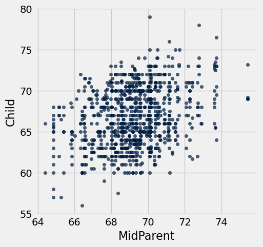

```python
heights.scatter('MidParent')
```

Use the `predict_child` function below to predict a child's hight based on a midparent height.

```python
def predict_child(h):
    """Return a prediction of the height of a child
    whose parents have a midparent height of h.

    The prediction is the average height of the children
    whose midparent height is in the range h plus or minus 0.5 inches.
    """

    close_points = heights.where('MidParent', are.between(h-0.5, h + 0.5))
    return close_points.column('Child').mean()
```

```python
heights_with_predictions = heights.with_column(
    'Prediction', heights.apply(predict_child, 'MidParent')
    )
```

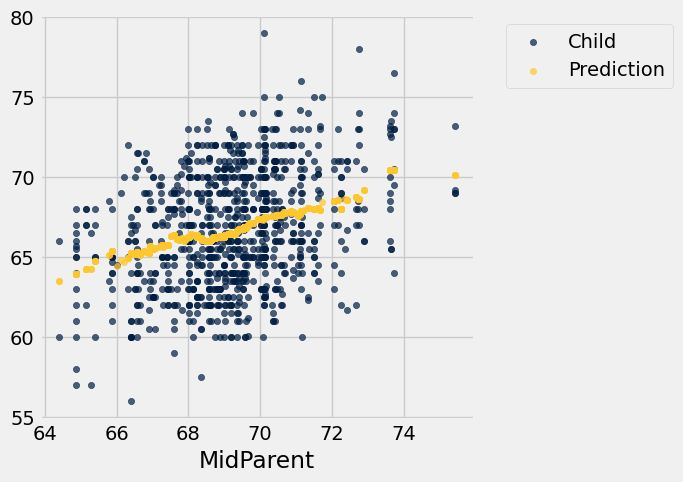

```python
heights_with_predictions.scatter('MidParent')
```

## Association

### Two Numerical Variables

- Trend
  - Positive association
  - Negative association
- Pattern
  - Any discernible "shape" in the scatter
  - Linear vs. Non-linear
- Visualize, then quantify

### Demo: Association

Load the `hybrid.csv` data on several older hybrid cars.

```python
hybrid = Table.read_table('data/hybrid.csv')
```

```python
hybrid
```

| vehicle | year | msrp | acceleration | mpg | class |
| --- | --- | --- | --- | --- | --- |
| Prius (1st Gen) | 1997 | 24509.7 | 7.46 | 41.26 | Compact |
| Tino | 2000 | 35355 | 8.2 | 54.1 | Compact |
| Prius (2nd Gen) | 2000 | 26832.2 | 7.97 | 45.23 | Compact |
| Insight | 2000 | 18936.4 | 9.52 | 53 | Two Seater |
| Civic (1st Gen) | 2001 | 25833.4 | 7.04 | 47.04 | Compact |
| Insight | 2001 | 19036.7 | 9.52 | 53 | Two Seater |
| Insight | 2002 | 19137 | 9.71 | 53 | Two Seater |
| Alphard | 2003 | 38084.8 | 8.33 | 40.46 | Minivan |
| Insight | 2003 | 19137 | 9.52 | 53 | Two Seater |
| Civic | 2003 | 14071.9 | 8.62 | 41 | Compact |

... (143 rows omitted)

```python
hybrid.sort('msrp', descending=True)
```

| vehicle | year | msrp | acceleration | mpg | class |
| --- | --- | --- | --- | --- | --- |
| Lexus LS600h/hL | 2007 | 118544 | 17.54 | 21 | Midsize |
| ActiveHybrid 7 | 2010 | 104300 | 20.41 | 22.11 | Large |
| ActiveHybrid 7i | 2011 | 102606 | 18.18 | 20 | Midsize |
| ActiveHybrid X6 | 2009 | 97237.9 | 17.96 | 18.82 | SUV |
| S400 Long | 2009 | 96208.9 | 13.89 | 26.34 | Large |
| Panamera S | 2013 | 96150 | 18.52 | 25 | Large |
| Panamera S | 2012 | 95283.9 | 17.54 | 25 | Large |
| S400 | 2013 | 92350 | 13.89 | 21 | Large |
| S400 | 2010 | 88212.8 | 12.99 | 21 | Large |
| ActiveHybrid 7L | 2013 | 84300 | 18.18 | 25 | Large |

... (143 rows omitted)

Visualize the relationship between several of the numerical variables.

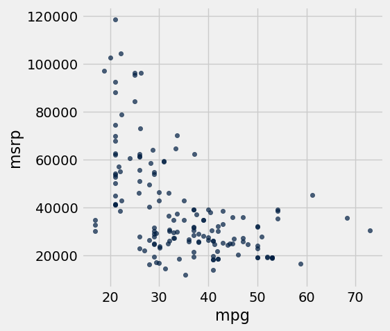

```python
hybrid.scatter('mpg', 'msrp')
```

- Nonlinear, but there is some kind of association
- Negative trend

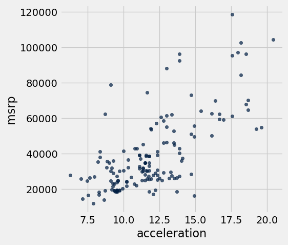

```python
hybrid.scatter('acceleration', 'msrp')
```

- Kind of linear --- MSRP seems to fan out a bit for the larger acceleration values
- Positive trend

```python
suv = hybrid.where('class', 'SUV')
suv.num_rows
```

```
39
```

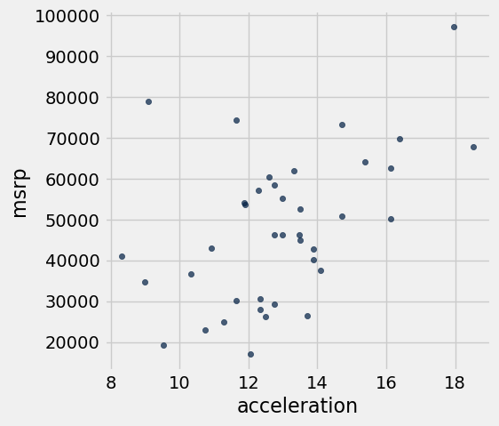

```python
suv.scatter('acceleration', 'msrp')
```

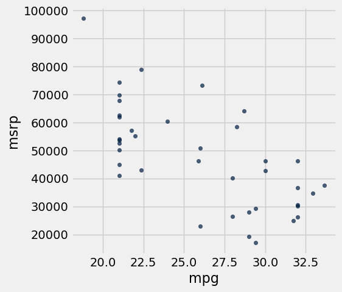

```python
suv.scatter('mpg', 'msrp')
```

Use the `standard_units` function bellow to visualize the relationship between `mpg` and `msrp` in standard units.

```python
def standard_units(x):
    "Convert any array of numbers to standard units."
    return (x - np.average(x)) / np.std(x)
```

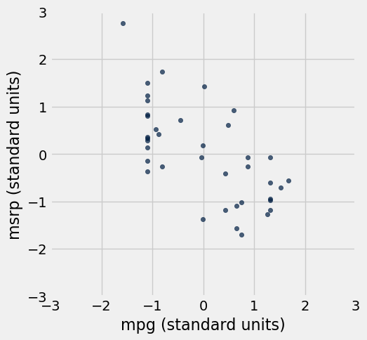

```python
Table().with_columns(
    'mpg (standard units)',  standard_units(suv.column('mpg')),
    'msrp (standard units)', standard_units(suv.column('msrp'))
).scatter(0, 1)
plots.xlim(-3, 3)
plots.ylim(-3, 3);
```

Use the `standard_units` function bellow to visualize the relationship between `acceleration` and `msrp` in standard units.

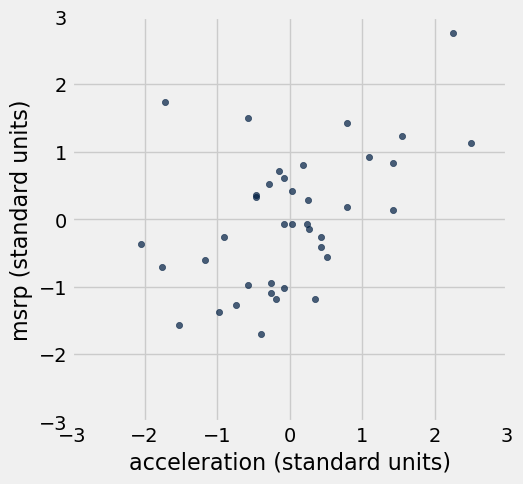

```python
Table().with_columns(
    'acceleration (standard units)', standard_units(suv.column('acceleration')),
    'msrp (standard units)',         standard_units(suv.column('msrp'))
).scatter(0, 1)
plots.xlim(-3, 3)
plots.ylim(-3, 3);
```

## Correlation Coefficient

### The Correlation Coefficient $r$

- Measures linear association
- Based on standard units
- $-1 \leq r \leq 1$
  - $r = 1$: scatter is perfect straight line sloping up
  - $r = -1$: scatter is perfect straight line sloping down
  - $r = 0$: No linear association; *uncorrelated*

### Definition of $r$

- Correlation Coefficient ($r$) =
  - average of
  - product of
  - $x$ in standard units
  - and
  - $y$ in standard units
- Measures how clustered the scatter is around a straight line

### Demo: Correlation

Demonstrate various scatter plots based on an inputted correlation coefficient using the `r_scatter` function.

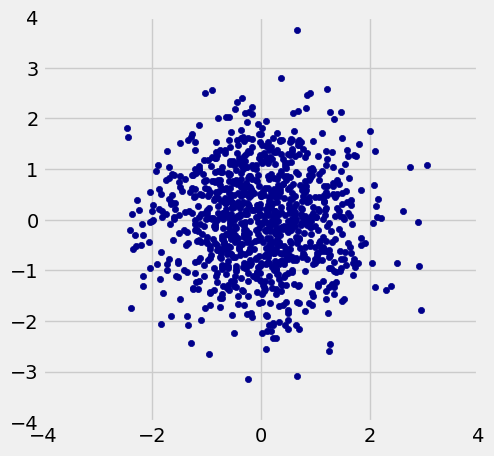

```python
r_scatter(0)
```

## Calculating $r$

Explore the concept of calculating the $r$ value.

```python
x = np.arange(1, 7, 1)
y = make_array(2, 3, 1, 5, 2, 7)
t = Table().with_columns(
        'x', x,
        'y', y
    )
t
```

| x | y |
| --- | --- |
| 1 | 2 |
| 2 | 3 |
| 3 | 1 |
| 4 | 5 |
| 5 | 2 |
| 6 | 7 |

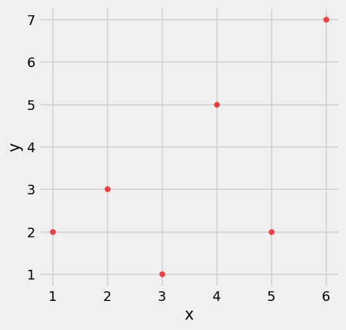

```python
t.scatter('x', 'y', s=30, color='red')
```

```python
t = t.with_columns(
        'x (standard units)', standard_units(x),
        'y (standard units)', standard_units(y)
    )
t
```

| x | y | x (standard units) | y (standard units) |
| --- | --- | --- | --- |
| 1 | 2 | -1.46385 | -0.648886 |
| 2 | 3 | -0.87831 | -0.162221 |
| 3 | 1 | -0.29277 | -1.13555 |
| 4 | 5 | 0.29277 | 0.811107 |
| 5 | 2 | 0.87831 | -0.648886 |
| 6 | 7 | 1.46385 | 1.78444 |

```python
t = t.with_columns('product of standard units',
                   t.column('x (standard units)') * t.column('y (standard units)'))
t
```

| x | y | x (standard units) | y (standard units) | product of standard units |
| --- | --- | --- | --- | --- |
| 1 | 2 | -1.46385 | -0.648886 | 0.949871 |
| 2 | 3 | -0.87831 | -0.162221 | 0.142481 |
| 3 | 1 | -0.29277 | -1.13555 | 0.332455 |
| 4 | 5 | 0.29277 | 0.811107 | 0.237468 |
| 5 | 2 | 0.87831 | -0.648886 | -0.569923 |
| 6 | 7 | 1.46385 | 1.78444 | 2.61215 |

Notice that $r$ is the average of the products of the standard units

```python
r = np.average(t.column('product of standard units'))
r
```

```
0.61741639718977093
```

Define `correlation` as a function for a given table and x, y column labels.

```python
def correlation(t, x, y):
    """t is a table; x and y are column labels"""
    x_in_standard_units = standard_units(t.column(x))
    y_in_standard_units = standard_units(t.column(y))
    return np.mean(x_in_standard_units * y_in_standard_units)
```

```python
correlation(t, 'x', 'y')
```

```
0.61741639718977093
```

```python
correlation(suv, 'mpg', 'msrp')
```

```
-0.6667143635709919
```

```python
correlation(suv, 'acceleration', 'msrp')
```

```
0.48699799279959155
```

## Care in Interpretation

### Watch Out For ...

- False conclusions of causation
- Nonlinearity
- Outliers
- Ecological Correlations

### Demo: Switching Axes

Notice that `correlation(t, 'x', 'y') == correlation(t, 'y', 'x')`. This can lead to a false conclusion of causation.

```python
correlation(t, 'x', 'y')
```

```
0.61741639718977093
```

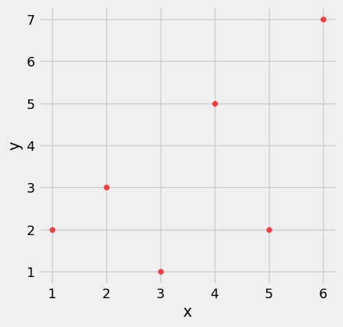

```python
t.scatter('x', 'y', s=30, color='red')
```

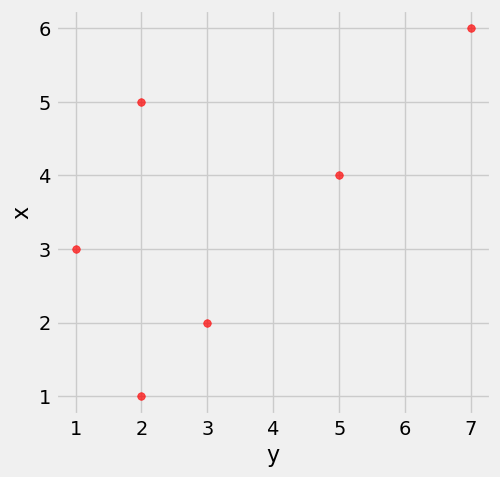

```python
t.scatter('y', 'x', s=30, color='red')
```

```python
correlation(t, 'y', 'x')
```

```
0.61741639718977093
```

### Demo: Nonlinearity

Explore the correlation calculation for symmetrical non-linear data.

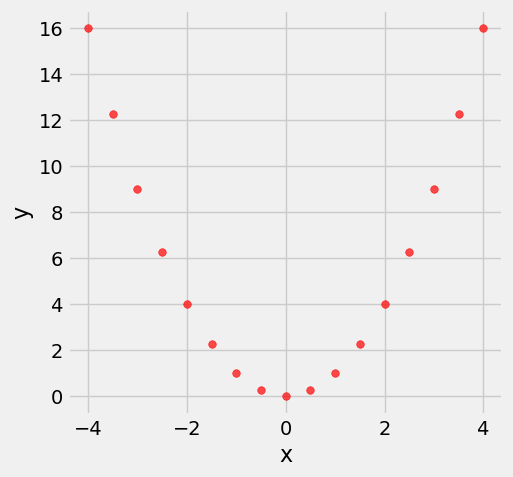

```python
new_x = np.arange(-4, 4.1, 0.5)
nonlinear = Table().with_columns(
        'x', new_x,
        'y', new_x**2
    )
nonlinear.scatter('x', 'y', s=30, color='r')
```

```python
correlation(nonlinear, 'x', 'y')
```

```
0.0
```

### Demo: Outliers

Notice how 1 outlier can strengthen or weaken an $r$ value depending on its value.

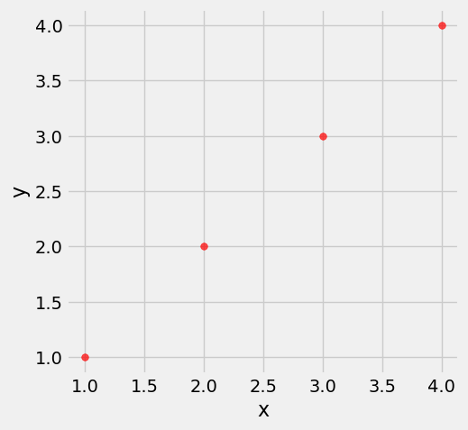

```python
line = Table().with_columns(
        'x', make_array(1, 2, 3, 4),
        'y', make_array(1, 2, 3, 4)
    )
line.scatter('x', 'y', s=30, color='r')
```

```python
correlation(line, 'x', 'y')
```

```
1.0
```

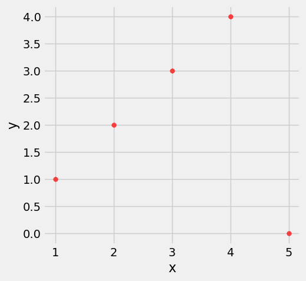

```python
outlier = Table().with_columns(
        'x', make_array(1, 2, 3, 4, 5),
        'y', make_array(1, 2, 3, 4, 0)
    )
outlier.scatter('x', 'y', s=30, color='r')
```

```python
correlation(outlier, 'x', 'y')
```

```
0.0
```

### Demo: Ecological Correlations

Explore an example of SAT scores (`sat2014.csv`) in connection to ecological correlations.

```python
sat2014 = Table.read_table('data/sat2014.csv').sort('State')
sat2014
```

| State | Participation Rate | Critical Reading | Math | Writing | Combined |
| --- | --- | --- | --- | --- | --- |
| Alabama | 6.7 | 547 | 538 | 532 | 1617 |
| Alaska | 54.2 | 507 | 503 | 475 | 1485 |
| Arizona | 36.4 | 522 | 525 | 500 | 1547 |
| Arkansas | 4.2 | 573 | 571 | 554 | 1698 |
| California | 60.3 | 498 | 510 | 496 | 1504 |
| Colorado | 14.3 | 582 | 586 | 567 | 1735 |
| Connecticut | 88.4 | 507 | 510 | 508 | 1525 |
| Delaware | 100 | 456 | 459 | 444 | 1359 |
| District of Columbia | 100 | 440 | 438 | 431 | 1309 |
| Florida | 72.2 | 491 | 485 | 472 | 1448 |

... (41 rows omitted)

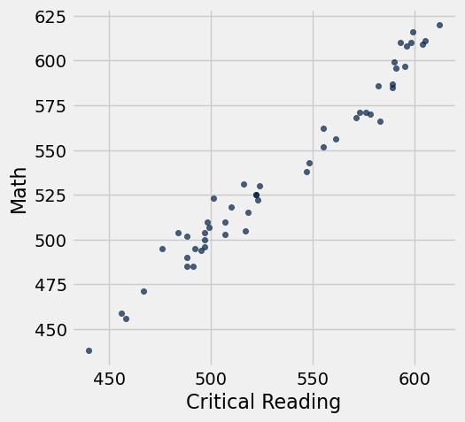

```python
sat2014.scatter('Critical Reading', 'Math')
```

```python
correlation(sat2014, 'Critical Reading', 'Math')
```

```
0.98475584110674341
```

### Reflection

For each pair, which one (left/right) will have a higher value of r?

[figure not shown]